# Jonah Crab in LFA 34: a DFO Case Study Operating model

Operating Model based on Male Life History Parameters

Adrian Hordyk, University of British Columbia a.hordyk@oceans.ubc.ca

April 2018

# Introduction

This document describes the Operating Model for male Jonah crab (*Cancer borealis*) in LFA (Lobster Fishing Area) 34, southwest Nova Scotia.

This operating model was primarily based on:

- Robichaud, D.A., and Frail, C. 2006. Development of Jonah crab, *Cancer borealis*, and rock crab, *Cancer irroratus*, fisheries in the Bay of Fundy (LFAs 35-38) and off southwest Nova Scotia (LFA 34): from exploratory to commercial status (1995-2004). Can. Manuscr. Rep. Fish. Aquat. Sci. 2775: iii + 48 pp.

Jonah crab have dimorphic growth patterns, with male crabs reaching larger size than females. Only male crabs are allowed to be retained in LFA 34. Because the population dynamics model in DLMtool is a single sex model the impact of the fishery on the male and female components of the population must be evaluated separately. Future developments of DLMtool will include a multi-species model which can account for different population and fishing dynamics between male and females. We have developed an operating model based on the male life history and selectivity parameters.

Jonah crab in LFA 34 is a data-limited stock, with little information available on the fundamental life-history parameters, including growth, natural mortality, maturity, and stock-recruitment relationship. The document describes a base-case OM, and represents the initial development of an OM for this data-limited stock. Given the large amount of uncertainty in the stock dynamics of Jonah crab, a number of alternative OMs are proposed as robustness tests. The OM should be revised as more information is made available from discussions with the Jonah crab fishery experts.

## Key Uncertainties and Robustness Tests

### Growth

The growth pattern of Jonah crab is not well known. The base case OM assumes that growth is described by a von Bertalanffy growth model, with the parameters based on reported size at age 6-7 and maximum size. The assumed growth curve in the base-case OM may under-estimate the uncertainty in length-at-age. A robustness OM should be developed with alternative assumptions regarding the growth pattern.

### Recruitment

This base-case model assumes that fishing of male crabs has little impact on the recruitment - i.e., a low population of male crabs does not lead to low recruitment. Robustness OMs can include two alternatives: 1) recruitment is strongly determined by male population size (low steepness), and 2) the impact of male population on recruitment in completely unknown (wide range of uncertainty on steepness).

### Changes in M

The base-case OM assumes that natural mortality (*M*) is age-independant and does not change over time. There is some evidence to suggest that the environment may be becoming more favourable for Jonah crab in LFA 34. This hypothesis can be included in an alternative OM by either including a gradient in *M* (`OM@Mgrad`) or by modelling a decrease in *M* in the future projections by including an array of natural mortality by year as custom parameters (`OM@cpars$Marray`).

### Current Depletion

Current depletion for Jonah crab is unknown. The base-case OM assumes that the male stock is between 0.1 and 0.3 of the unfished level. Alternative assumptions could include both a highly depleted and a high abundance OM.

### Discard mortality

The base-case OM assumes that some sub-legal (<130 mm) crabs are selected by the fishing gear (i.e., don’t escape the traps) and are subject to quite high discard mortality. This assumption is based on reports that some crabs are used a bait. The bounds for the discard mortality in the base-case OM are somewhat arbitrary and may need to be revised after discussion with the Jonah crab fishery experts.

### Historical Fishing Effort

Data on historical fishing effort is sparse. The pattern in historical fishing effort in the base-case OM is based on information in Robichaud and Frail (2006) and the available fishery logbook data from LFA 34. This data indicates that fishing effort begain in 1996 and first increased to a maximum in 2001, before declining to a minimum around 2004/2005. Since 2005 fishing effort increased again and passed the 2001 level in 2008, and has since remained relatively stable.

Further discussion with the Jonah crab fishery experts is required to determine if this pattern in fishing effort adequately describes the history of the fishery. Alternative assumptions of historical fishing effort, particularly the pattern in recent years, may be explored in alternative robustness OMs.

### Observation Parameters

There appears to be little fishery data for Jonah crab in LFA 34. The observation parameters (Obs) are based on the Generic_Obs in DLMtool.

# Operating Model

The OM rdata file can be downloaded from here

Download and import into R using `myOM <- readRDS('OM.rdata')`

## Species Information

**Species**: *Cancer borealis*

**Common Name**: *Jonah crab*

**Management Agency**: DFO

**Region**: southwest Nova Scotia

## OM Parameters

**OM Name**: Name of the operating model: Jonah_Crab_LFA34_DFO

**proyears**: The number of projected years: 50

**interval**: The assessment interval - how often would you like to update the management system? 4

**pstar**: The percentile of the sample of the management recommendation for each method: 0.5

**maxF**: Maximum instantaneous fishing mortality rate that may be simulated for any given age class: 0.8

**reps**: Number of samples of the management recommendation for each method. Note that when this is set to 1, the mean value of the data inputs is used. 1

**Source**: A reference to a website or article from which parameters were taken to define the operating model

See OM Report

# Stock Parameters

### Mortality and age: maxage, R0, M, Msd

**maxage**: The maximum age of individuals that is simulated (there is no plus group ). Single value. Positive integer

Specified Value(s): 14

No information could be found on the longevity or natural mortality rate for Jonah crab. Sheehy and Prior (2008) report a longevity of 9 years and estimate *M* of 0.48 for the closely related *C. pagurus*. Shields (1991) report that the maximum age of several species from the genus *Cancer* ranges from 4 - 8 years. Lacking any additional information, and given the large uncertainty, we set the maximum age to 1.5 times the maximum reported age for *C. pagurus*. This parameter is used to determine the maximum number of age classes in the model and, provided that it is high enough, the model results are not sensitive to this parameter.

**R0**: The magnitude of unfished recruitment. Single value. Positive real number

Specified Value(s): 1000

Unless management options are specified in absolute numbers (e.g. tonnes) the MSE is scale-less (has no units) and this value is inconsequential. Here it is set to 1000 arbitrarily.

**M**: Natural mortality rate. Uniform distribution lower and upper bounds. Positive real number

Specified Value(s): 0.32, 0.57

By assuming that *M*-at-age is constant and following the commonly used rule-of-thumb that 1% of an initial cohort survives to maximum age, we calculate a lower bound for *M* by: $-\ln(0.01)/14 = 0.32$. We determine the upper bound for *M* using the same equation, and somewhat arbitrarily, a maximum age of 8 years.

**Msd**: Inter-annual variability in natural mortality rate expressed as a coefficient of variation. Uniform distribution lower and upper bounds. Non-negative real numbers

Specified Value(s): 0, 0.1

We allow for some inter-annual variation in *M*.

### Natural Mortality Parameters

#### Sampled Parameters

Histograms of simulations of `M`, and `Msd` parameters, with vertical colored lines indicating 3 randomly drawn values used in other plots:

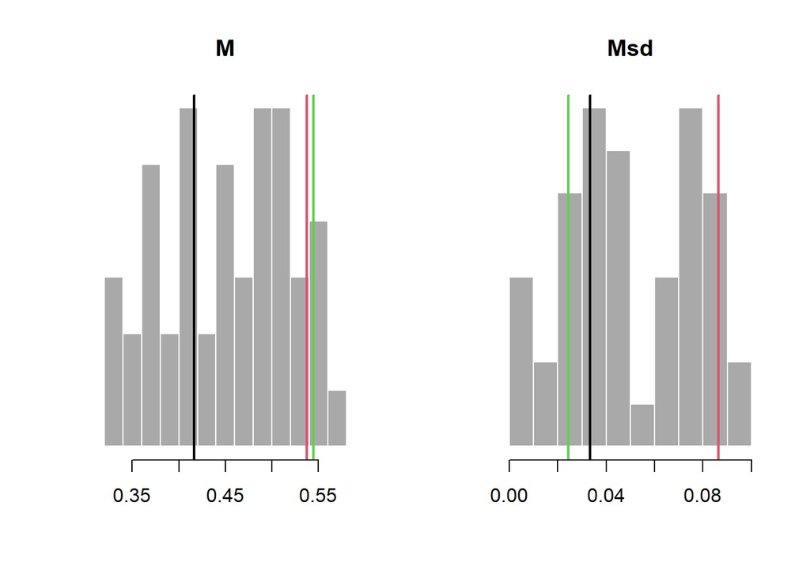

#### Time-Series

The average natural mortality rate by year for adult fish for 3 simulations. The vertical dashed line indicates the end of the historical period:

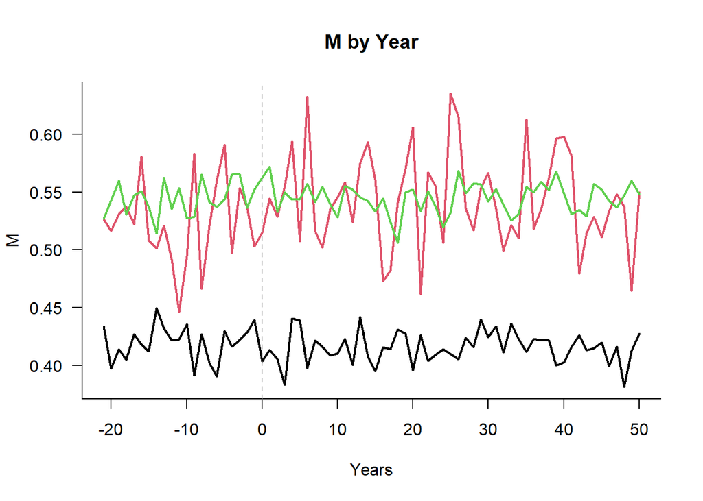

#### M-at-Age

Natural mortality-at-age for 3 simulations in the first historical year, the last historical year (i.e., current year), and the last projected year:

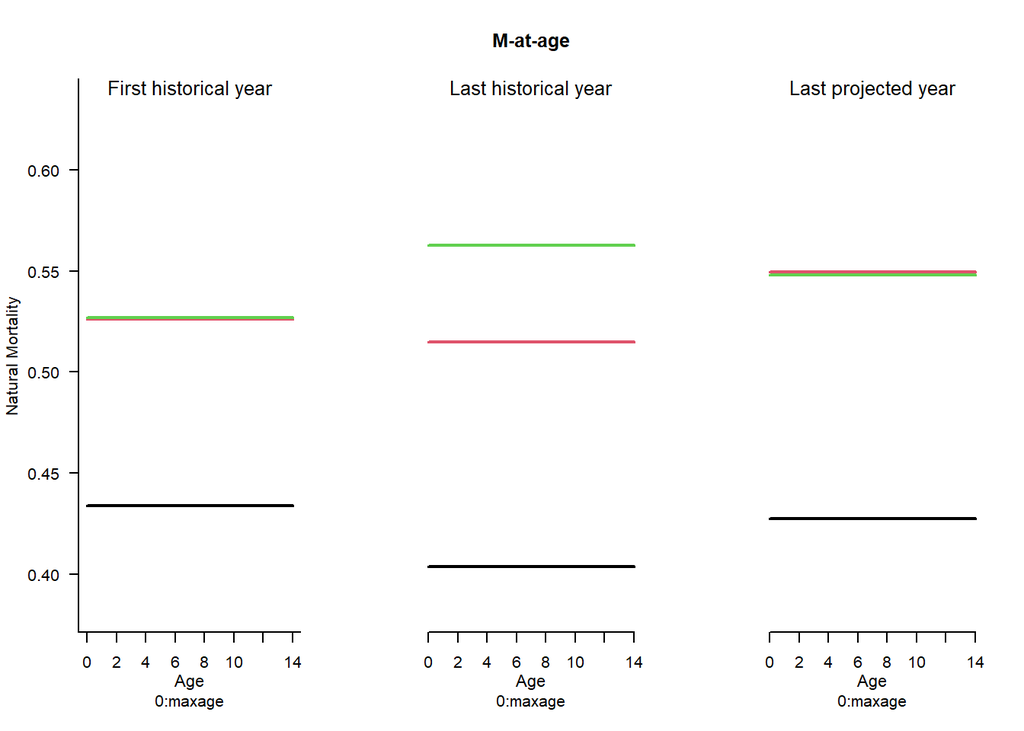

#### M-at-Length

Natural mortality-at-length for 3 simulations in the first historical year, the last historical year (i.e., current year), and the last projected year:

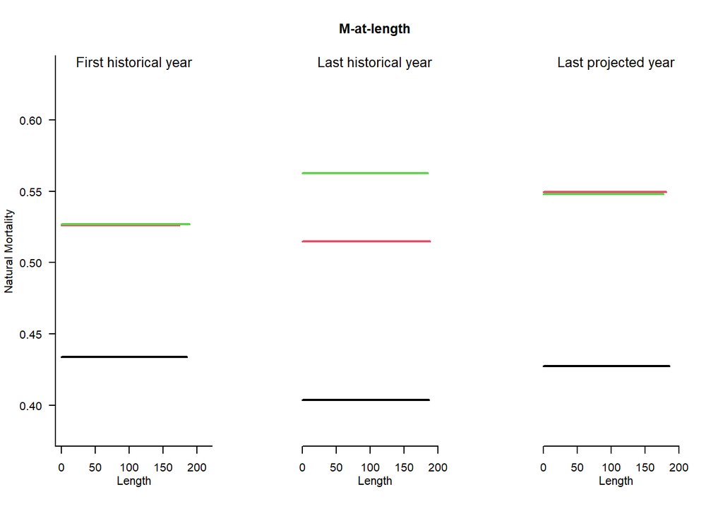

### Recruitment: h, SRrel, Perr, AC

**h**: Steepness of the stock recruit relationship. Uniform distribution lower and upper bounds. Values from 1/5 to 1

Specified Value(s): 0.9, 0.95

Some crab stocks have been found to remain highly productive at low stock sizes which suggests that there is high steepness in the stock-recruitment relationship. Because regulations forbid the retention of female crabs, the female spawning stock is likely to experience low fishing mortality compared to the male population. Consequently, we have assumed that steepness is high in this OM, assuming that spawning output will remain high even when the male biomass is reduced to low levels.

This assumption is sensitive to the assumption that females experience low fishing mortality (e.g discard mortality on females is low) and that spawning potential is not compromised by fishing the male stock.

Alternative assumptions are investigated in the Robustness Tests.

**SRrel**: Type of stock-recruit relationship. Single value, switch (1) Beverton-Holt (2) Ricker. Integer

Specified Value(s): 1

No information is available on the stock-recruitment relationship. We are using the DLMtool default and assuming a Beverton-Holt stock-recruitment curve.

**Perr**: Process error, the CV of log-normal recruitment deviations. Uniform distribution lower and upper bounds. Non-negative real numbers

Specified Value(s): 0.6, 0.9

There is insufficient data to evaluate recruitment trends for Jonah crab (Pezzack et al 2011). Cobb et al. (1997) suggest that, due to the duration of the larval period and a coastal distribution, *Cancer* species are likely to have moderately high recruitment variability. We set a wide range for this parameter to reflect the uncertainty in recruitment dynamics.

**AC**: Auto-correlation in recruitment deviations rec(t)=AC*rec(t-1)+(1-AC)*sigma(t). Uniform distribution lower and upper bounds. Non-negative real numbers

Specified Value(s): 0.1, 0.9

We set a wide range in this parameter to reflect the high uncertainty.

### Recruitment Parameters

#### Sampled Parameters

Histograms of 48 simulations of steepness (`h`), recruitment process error (`Perr`) and auto-correlation (`AC`) for the Beverton-Holt stock-recruitment relationship, with vertical colored lines indicating 3 randomly drawn values used in other plots:

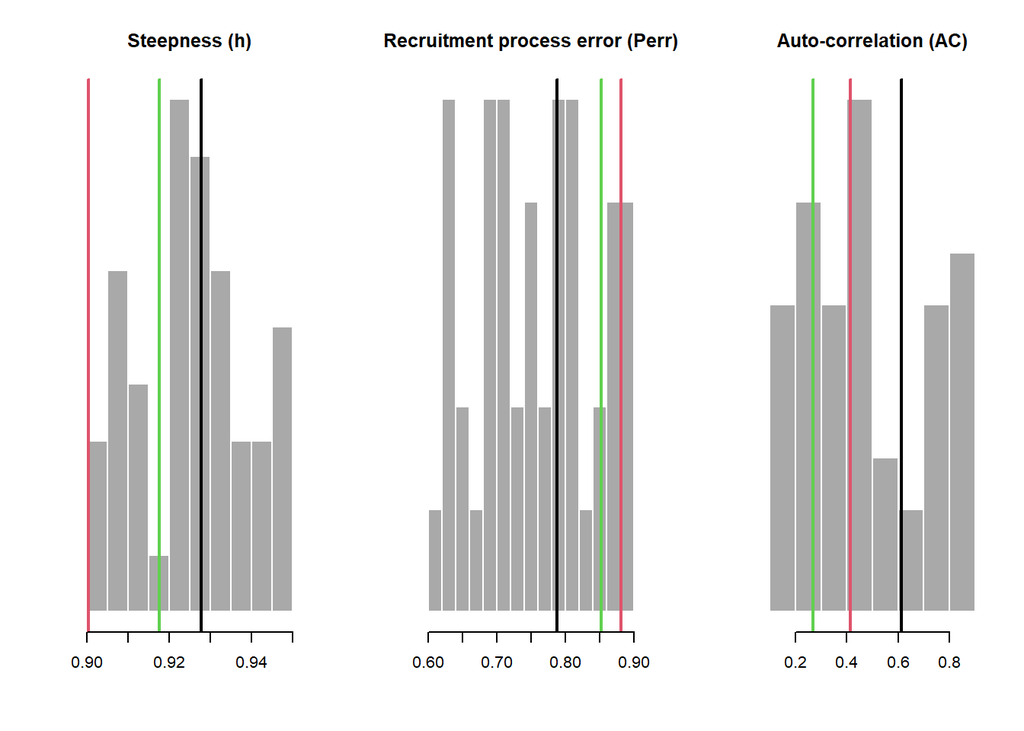

#### Time-Series

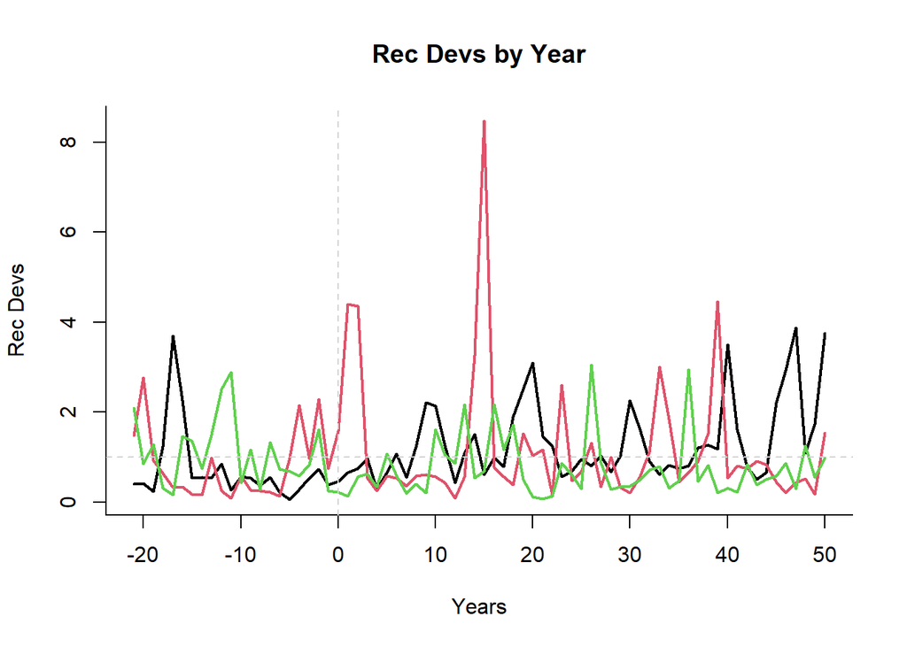

### Growth: Linf, K, t0, LenCV, Ksd, Linfsd

**Linf**: Maximum length. Uniform distribution lower and upper bounds. Positive real numbers

Specified in cpars: 210.93, 233.1

There do not appear to be any published studies of the growth curve for Jonah crab, although there is evidence that male crabs reach a larger size than females. Pezzack et al (2011) report that males reach 222 mm carapace width (CW). No other information was available on the growth curve for *C. borealis*. We assumed a mean Linf of 222 mm and assumed a lower and upper bound of 0.95 and 1.05 x 222.

**K**: von Bertalanffy growth parameter k. Uniform distribution lower and upper bounds. Positive real numbers

Specified in cpars: 0.12, 0.16

Without reliable size-at-age or tagging data it is difficult to estimate the parameters of the growth curve. Anon. (2013) report that male crabs reach 130 mm CW in 6-7 years. Assuming this information is reliable and reflective of the Jonah crab stock, this information can be used to obtain estimates of the von Bertalanffy K parameter by optimizing for *K* assuming CW = 130 mm at ages 6-7 years while accounting for the uncertainty in *Linf*:

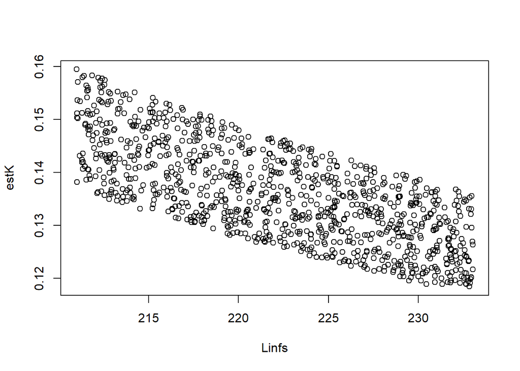

```r
nsamp <- 1000
Linfs <- runif(nsamp, 0.95*222, 1.05*222)
Ages <- runif(nsamp, 6, 7)
VB <- function(Linf, K, Ages) Linf *(1-exp(-K * Ages))
Kopt <- function(logK, Linf, Ages, expLen)   (expLen - VB(Linf, exp(logK), Ages))^2


estK <- sapply(1:nsamp, function(x)
  exp(optimize(Kopt, interval=log(c(0.01, 1)), Linf=Linfs[x], Ages=Ages[x], expLen=130)$minimum))


plot(Linfs, estK)
```

This analysis is rather crude and may be overly optimistic with respect to the uncertainty in the growth curve. The ranges for the growth parameters should be updated if more information is available.

The correlated estimates of *Linf* and *K* are provided to the OM as Custom Parameters

**t0**: von Bertalanffy theoretical age at length zero. Uniform distribution lower and upper bounds. Non-positive real numbers

Specified Value(s): 0, 0

Based on the small size for age-1 individuals and a lack of additional information on growth, size at age 0 is assumed to be 0.

**LenCV**: Coefficient of variation of length-at-age (assumed constant for all age classes). Uniform distribution lower and upper bounds. Positive real numbers

Specified Value(s): 0.08, 0.12

No information could be found on the variation of size-at-age for the Jonah crab. The DLMtool default range was used.

**Ksd**: Inter-annual variability in growth parameter k expressed as coefficient of variation. Uniform distribution lower and upper bounds. Non-negative real numbers

Specified Value(s): 0, 0.05

No information is available. A broad range was used allowing some variation in K between years.

**Linfsd**: Inter-annual variability in maximum length expressed as a coefficient of variation. Uniform distribution lower and upper bounds. Non-negative real numbers

Specified Value(s): 0, 0.05

No information is available. A broad range was used allowing some variation in asymptotic length between years.

### Growth Parameters

#### Sampled Parameters

Histograms of simulations of von Bertalanffy growth parameters `Linf`, `K`, and `t0`, and inter-annual variability in Linf and K (`Linfsd` and `Ksd`), with vertical colored lines indicating 3 randomly drawn values used in other plots:

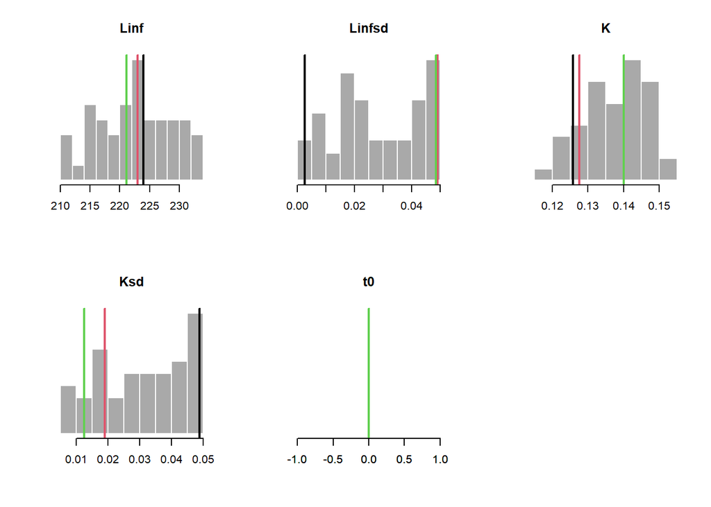

#### Time-Series

The Linf and K parameters in each year for 3 simulations. The vertical dashed line indicates the end of the historical period:

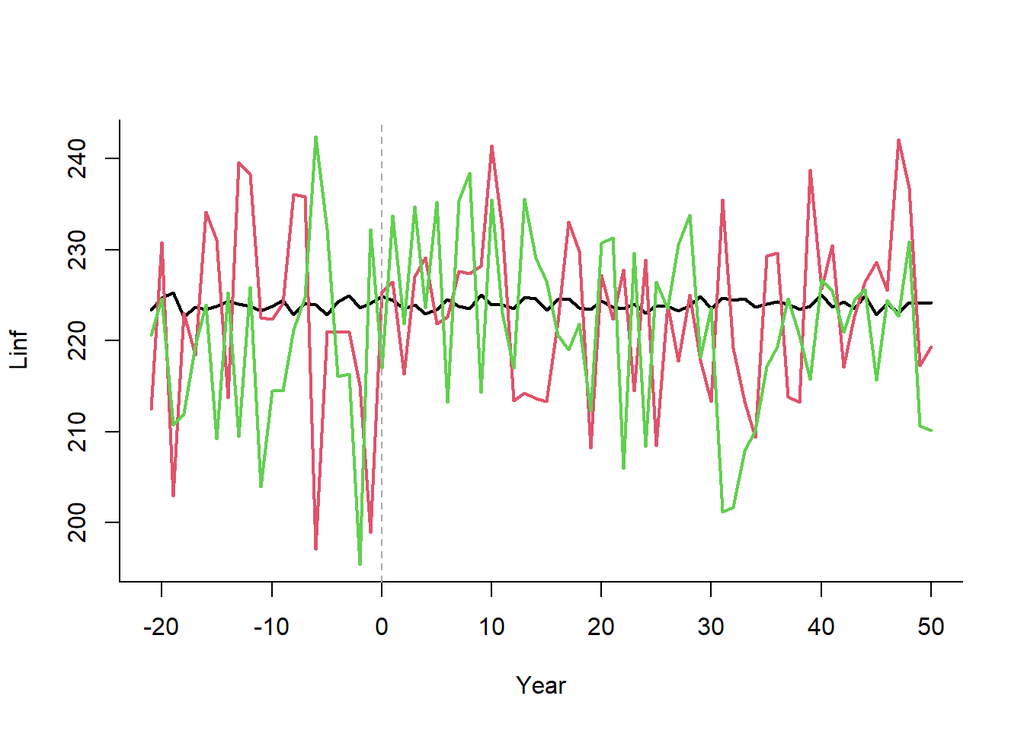

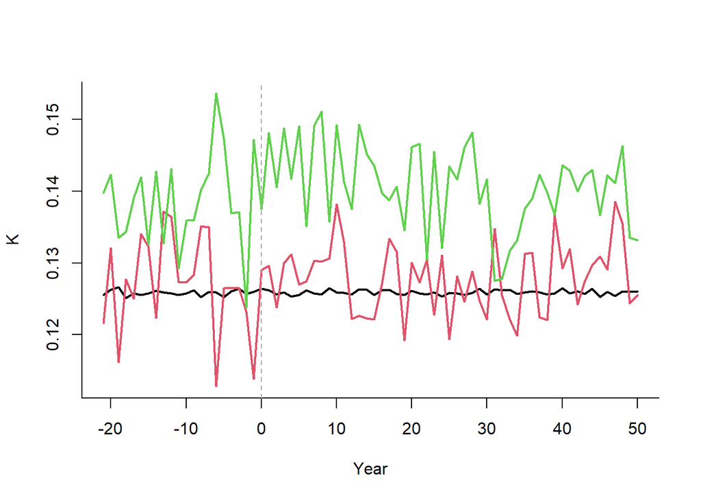

#### Growth Curves

Sampled length-at-age curves for 3 simulations in the first historical year, the last historical year, and the last projection year.

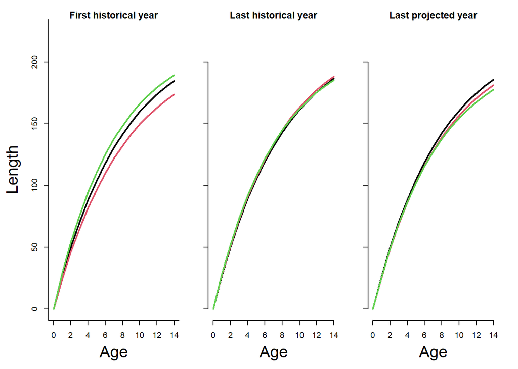

### Maturity: L50, L50_95

**L50**: Length at 50 percent maturity. Uniform distribution lower and upper bounds. Positive real numbers

Specified Value(s): 115.2, 140.8

There appears to be little information on the size of maturation. Moriyasu et al (2002) report that the estimated size of 50% maturity for male crabs on the Scotian shelf is 128 mm mm CW. No other estimates of size-at-maturity are available, so it is difficult to determine the uncertainty in this parameter. An arbitrary bracketing of +/- 10% around 128 mm is used.

**L50_95**: Length increment from 50 percent to 95 percent maturity. Uniform distribution lower and upper bounds. Positive real numbers

Specified Value(s): 5, 20

A relatively wide range is assumed for the length increment between 50% and 95% maturity.

### Maturity Parameters

#### Sampled Parameters

Histograms of simulations of `L50` (length at 50% maturity), `L95` (length at 95% maturity), and corresponding derived age at maturity parameters (`A50` and `A95`), with vertical colored lines indicating 3 randomly drawn values used in other plots:

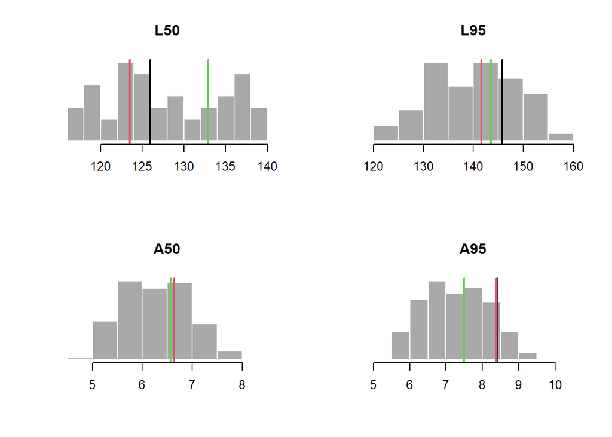

#### Maturity at Age and Length

Maturity-at-age and -length for 3 simulations in the first historical year, the last historical year (i.e., current year), and the last projected year:

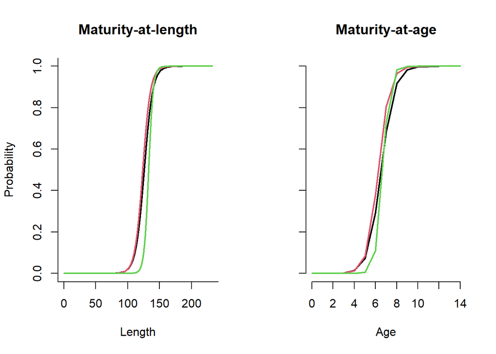

### Stock depletion and Discard Mortality: D, Fdisc

**D**: Current level of stock depletion SSB(current)/SSB(unfished). Uniform distribution lower and upper bounds. Fraction

Specified Value(s): 0.1, 0.3

There are no estimates of depletion for this stock. There are no estimates of abundance for recent years. For this base case analysis we assume a range for depletion that reflects an over-exploited male stock.

The sensitivity of the assumption of current depletion on the selection of an MP is evaluated in the Robustness Tests.

**Fdisc**: Fraction of discarded fish that die. Uniform distribution lower and upper bounds. Non-negative real numbers

Specified Value(s): 0.3, 0.6

Jonah crab are predominantly caught by traps, and only male crabs are permitted to be retained. There is no information on the level of fishing mortality on discarded individuals. However, there is some anecdotal evidence that suggests some crabs are used as bait which suggests that discard mortality is high. In this base case analysis we assume a moderately high discard mortality. Alternative levels of discard mortality could be evaluated in Robustness Tests.

### Depletion and Discard Mortality

#### Sampled Parameters

Histograms of simulations of depletion (spawning biomass in the last historical year over average unfished spawning biomass; `D`) and the fraction of discarded fish that are killed by fishing mortality (`Fdisc`), with vertical colored lines indicating 3 randomly drawn values.

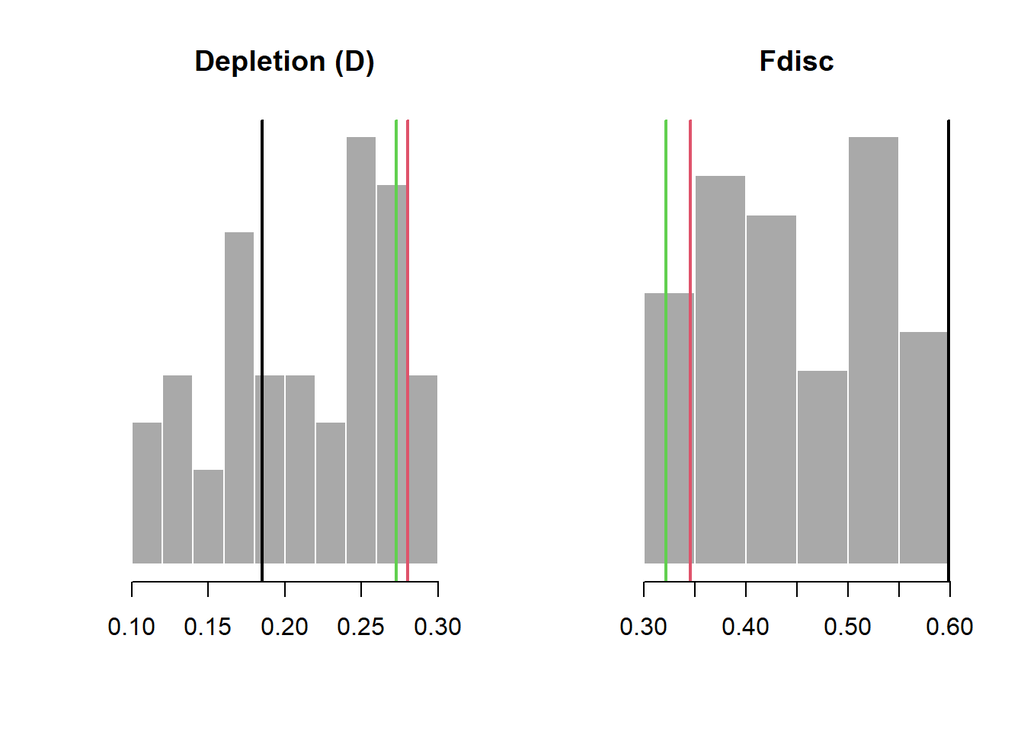

### Length-weight conversion parameters: a, b

**a**: Length-weight parameter alpha. Single value. Positive real number

Specified Value(s): 0.04

No information was available for the length-weight relationship for *C. borealis*. We used the estimated the carapace width-weight relationship for the closely related *C. irroratus* (Hudon and Lamarche, 1989).

**b**: Length-weight parameter beta. Single value. Positive real number

Specified Value(s): 2.67

See above.

### Spatial distribution and movement: Size_area_1, Frac_area_1, Prob_staying

**Size_area_1**: The size of area 1 relative to area 2. Uniform distribution lower and upper bounds. Positive real numbers

Specified Value(s): 0.5, 0.5

There are no current or proposed spatial closures for Jonah crab in LFA 34. Consequently, we simulate a fully mixed stock. The spatial parameters should be revisited if a spatial closure is proposed for this fishery.

**Frac_area_1**: The fraction of the unfished biomass in stock 1. Uniform distribution lower and upper bounds. Positive real numbers

Specified Value(s): 0.5, 0.5

See Size_area_1

**Prob_staying**: The probability of individuals in area 1 remaining in area 1 over the course of one year. Uniform distribution lower and upper bounds. Positive fraction.

Specified Value(s): 0.5, 0.5

See Size_area_1

### Spatial & Movement

#### Sampled Parameters

Histograms of 48 simulations of size of area 1 (`Size_area_1`), fraction of unfished biomass in area 1 (`Frac_area_1`), and the probability of staying in area 1 in a year (`Frac_area_1`), with vertical colored lines indicating 3 randomly drawn values used in other plots:

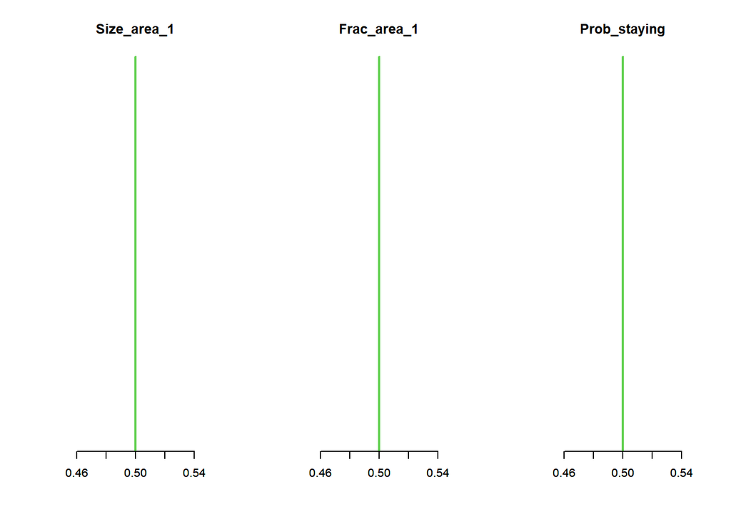

# Fleet Parameters

### Historical years of fishing, spatial targeting: nyears, Spat_targ

**nyears**: The number of years for the historical spool-up simulation. Single value. Positive integer

Specified Value(s): 22

The fishery for Jonah crab in LFA 34 began in 1996 (Robichaud and Frail, 2006). For the base case analysis we assume the stock was in a unfished state prior to 1996 and set the length of exploitation period to 22 years. It is possible that there was some fishing mortality on Jonah crab in LFA 34 prior to 1996 due to the species being caught as by-catch by the lobster fleet. Alternative assumptions on the historical fishery are explored in the Robustness Tests.

**Spat_targ**: Distribution of fishing in relation to spatial biomass: fishing distribution is proportional to B^Spat_targ. Uniform distribution lower and upper bounds. Real numbers

Specified Value(s): 1, 1

We are using the default level of 1 which assumes that effort is distributed in proportion to density.

### Trend in historical fishing effort (exploitation rate), interannual variability in fishing effort: EffYears, EffLower, EffUpper, Esd

**EffYears**: Years representing join-points (vertices) of time-varying effort. Vector. Non-negative real numbers

Robichaud and Frail (2006) report fishing effort, in terms of number of trap hauls, for LFA 34 from 1996 to 2004 (see image below). They report that fishing effort increased to a maximum of 59,955 thousand trap hauls in 2001, followed by a 73% decline to 15,954 thousand in 2004.

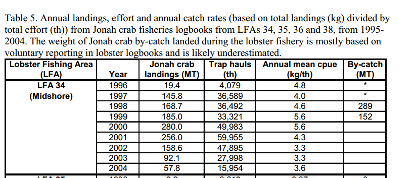

Total fishing effort from 1996 to 2004 for Jonah crab in LFA 34 (Robichaud and Frail, 2006)

We were not able to reproduce the effort time-series reported in Robichaud and Frail (2006) from the Jonah crab logbook data that was provided to us. The effort data in the log-book data began was available from 2002 to 2016 and was different (unknown) units compared that reported in Robichaud and Frail (2006). We generated an adjusted effort time-series from 1996 to 2016 by scaling the effort reported in Robichaud and Frail (2006).

We generated an adjusted effort time-series from 1996 to 2016 by calculating the ratio of the 2003 and 2004 records for the two data sets, and using the average ratio to scale the effort reported in Robichaud and Frail (2006) to the same units reported in the logbook data set.

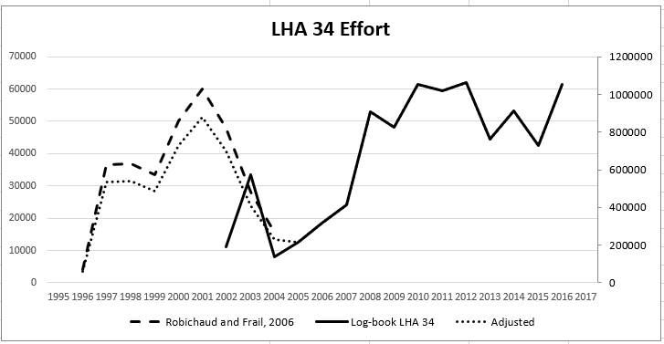

Time-series of fishing effort for LHA 34 reported in Robichaud and Frail (2006), the available log-book data, and the combined adjusted time-series used in the OM

**EffLower**: Lower bound on relative effort corresponding to EffYears. Vector. Non-negative real numbers

See EffYears

**EffUpper**: Upper bound on relative effort corresponding to EffYears. Vector. Non-negative real numbers

See EffYears

| EffYears | EffLower | EffUpper |
| --- | --- | --- |
| 1995 | 0.0000 | 0.0000 |
| 1996 | 0.0392 | 0.0728 |
| 1997 | 0.3520 | 0.6530 |
| 1998 | 0.3550 | 0.6600 |
| 1999 | 0.3200 | 0.5950 |
| 2000 | 0.4800 | 0.8920 |
| 2001 | 0.5760 | 1.0700 |
| 2002 | 0.4600 | 0.8550 |
| 2003 | 0.2690 | 0.5000 |
| 2004 | 0.1500 | 0.2790 |
| 2005 | 0.1410 | 0.2610 |
| 2006 | 0.2070 | 0.3840 |
| 2007 | 0.2720 | 0.5060 |
| 2008 | 0.5970 | 1.1100 |
| 2009 | 0.5430 | 1.0100 |
| 2010 | 0.6910 | 1.2800 |
| 2011 | 0.6710 | 1.2500 |
| 2012 | 0.7000 | 1.3000 |
| 2013 | 0.5020 | 0.9320 |
| 2014 | 0.6010 | 1.1200 |
| 2015 | 0.4790 | 0.8890 |
| 2016 | 0.6930 | 1.2900 |

**Esd**: Additional inter-annual variability in fishing mortality rate. Uniform distribution lower and upper bounds. Non-negative real numbers

Specified Value(s): 0.1, 0.3

We included some additional variability in historical fishing effort.

### Historical Effort

#### Sampled Parameters

Histograms of 48 simulations of inter-annual variability in historical fishing mortality (`Esd`), with vertical colored lines indicating 3 randomly drawn values used in the time-series plot:

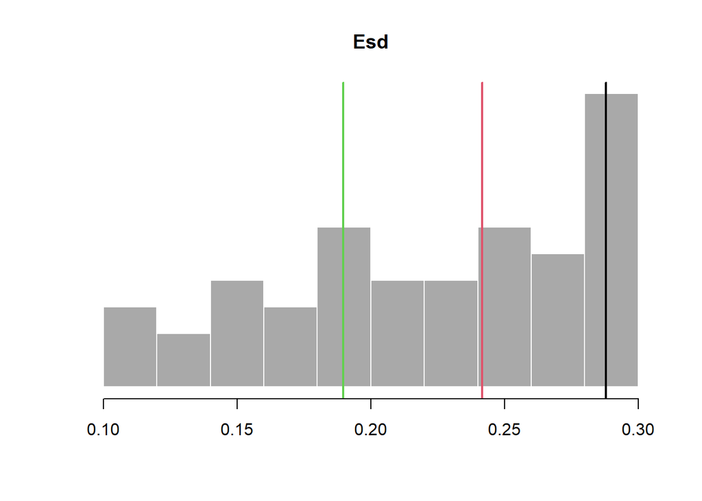

#### Time-Series

Time-series plot showing 3 trends in historical fishing mortality (`OM@EffUpper` and `OM@EffLower` or `OM@cpars$Find`):

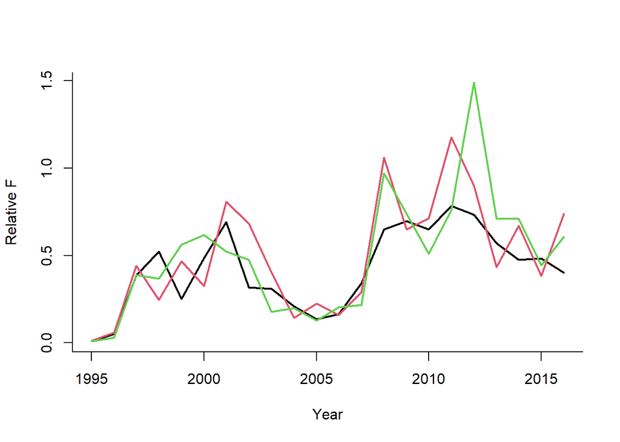

### Annual increase in catchability, interannual variability in catchability: qinc, qcv

**qinc**: Average percentage change in fishing efficiency (applicable only to forward projection and input controls). Uniform distribution lower and upper bounds. Non-negative real numbers

Specified Value(s): 0, 1

Pezzack et al (2010) note that fishers in LFA 41 continually experiment with trap design and bait to optimize catch and expect that over time the effectiveness of the traps will increase. We assume that fishers in LFA 34 are similiar and assume up to a 1% annual increase in catchability.

**qcv**: Inter-annual variability in fishing efficiency (applicable only to forward projection and input controls). Uniform distribution lower and upper bounds. Non-negative real numbers

Specified Value(s): 0.1, 0.3

The expected inter-annual variablity in catchability is unknown. We used the default DLMtool values to allow for some variability in catchability between years.

### Future Catchability

#### Sampled Parameters

Histograms of 48 simulations of inter-annual variability in fishing efficiency (`qcv`) and average annual change in fishing efficiency (`qinc`), with vertical colored lines indicating 3 randomly drawn values used in the time-series plot:

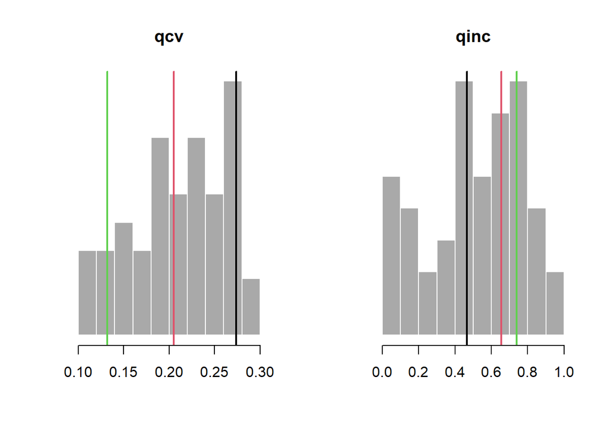

#### Time-Series

Time-series plot showing 3 trends in future fishing efficiency (catchability):

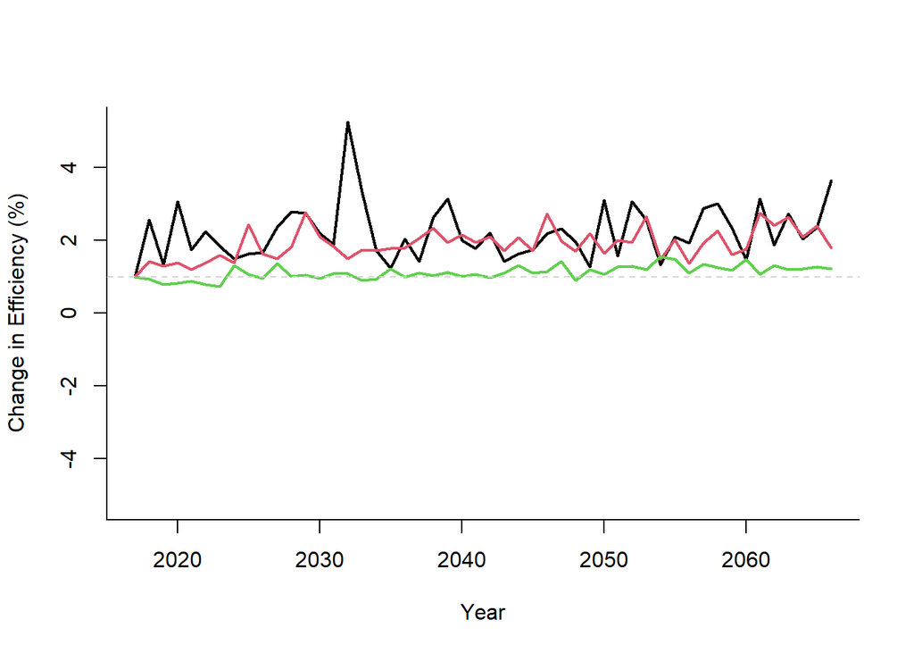

### Fishery gear length selectivity: L5, LFS, Vmaxlen, isRel

**L5**: Shortest length corresponding to 5 percent vulnerability. Uniform distribution lower and upper bounds. Positive real numbers

Specified Value(s): 120, 125

Size frequency data from the industry sampling suggests that few male crabs below the legal minimum length of 130 mm are caught in the vented traps. We set the length at 5% selection at the size that male crabs first start being retained by the vented traps, and the length at full selection at the legal minimum length.

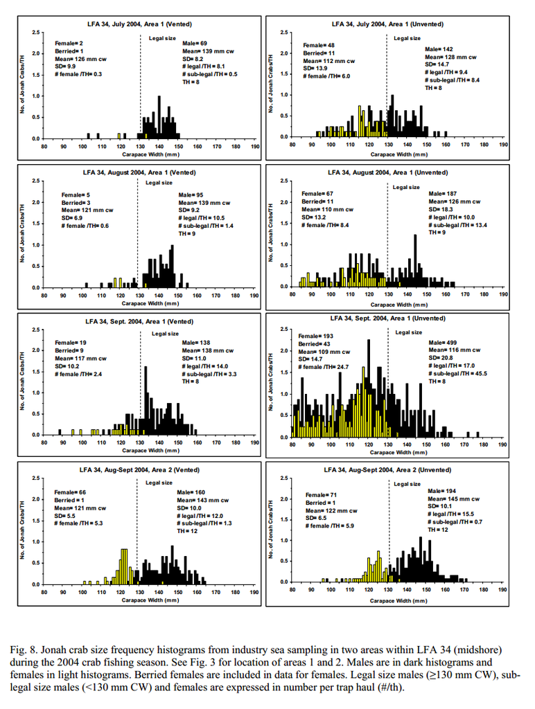

Size frequencies of Jonah crab in LHA 34 from industry sampling (Robichaud and Frail, 2006)

**LFS**: Shortest length that is fully vulnerable to fishing. Uniform distribution lower and upper bounds. Positive real numbers

Specified Value(s): 130, 131

See above.

**Vmaxlen**: The vulnerability of fish at Stock@Linf . Uniform distribution lower and upper bounds. Fraction

Specified Value(s): 1, 1

There is no evidence of dome-shaped selection by the fishing gear, and we assume that selectivity is asymptotic.

**isRel**: Selectivity parameters in units of size-of-maturity (or absolute eg cm). Single value. Boolean

Specified Value(s): FALSE

Selectivity parameters are in absolute units.

### Fishery length retention: LR5, LFR, Rmaxlen, DR

**LR5**: Shortest length corresponding ot 5 percent retention. Uniform distribution lower and upper bounds. Non-negative real numbers

Specified Value(s): 127, 128

Size of retention was set to the 130 mm CW size regulation.

**LFR**: Shortest length that is fully retained. Uniform distribution lower and upper bounds. Non-negative real numbers

Specified Value(s): 130, 131

See above.

**Rmaxlen**: The retention of fish at Stock@Linf . Uniform distribution lower and upper bounds. Non-negative real numbers

Specified Value(s): 1, 1

We assumed that all legal crabs are retained (i.e large-size crabs are not returned to the water)

**DR**: Discard rate - the fraction of caught fish that are discarded. Uniform distribution lower and upper bounds. Fraction

Specified Value(s): 0, 0

This base case analysis models the male part of the population. As this is a male only fishery, we assume that there is no general discarding of male crabs.

### Current Year: CurrentYr

**CurrentYr**: The current calendar year (final year) of the historical simulations (eg 2011). Single value. Positive integer

Specified Value(s): 2016

The current calendar year.

### Existing Spatial Closures: MPA

**MPA**: Is Area 1 currently closed (TRUE) or open (FALSE)? Defaults to FALSE

Specified Value(s): FALSE

No justification provided.

# Obs Parameters

The observation model parameter are taken from the Generic_Obs model subject to a few additional changes which are documented here. The Obs parameters should be updated after discussion with the Jonah crab stock experts.

### Catch statistics: Cobs, Cbiascv, CAA_nsamp, CAA_ESS, CAL_nsamp, CAL_ESS

**Cobs**: Log-normal catch observation error expressed as a coefficient of variation. Uniform distribution lower and upper bounds. Non-negative real numbers

Specified Value(s): 0.1, 0.3

Borrowed from Generic_Obs

**Cbiascv**: Log-normal coefficient of variation controlling the sampling of bias in catch observations for each simulation. Single value. Non-negative real number

Specified Value(s): 0.3

**CAA_nsamp**: Number of catch-at-age observation per time step. Uniform distribution lower and upper bounds. Positive real numbers

Specified Value(s): 10, 20

There is no catch-at-age data for Jonah crab.

**CAA_ESS**: Effective sample size (independent age draws) of the multinomial catch-at-age observation error model. Uniform distribution lower and upper bounds. Positive integers

Specified Value(s): 5, 5

There is no catch-at-age data for Jonah crab.

**CAL_nsamp**: Number of catch-at-length observation per time step. Uniform distribution lower and upper bounds. Positive integers

Specified Value(s): 10, 20

Borrowed from Generic_Obs

**CAL_ESS**: Effective sample size (independent length draws) of the multinomial catch-at-length observation error model. Uniform distribution lower and upper bounds. Positive integers

Specified Value(s): 5, 5

Borrowed from Generic_Obs

### Index imprecision, bias and hyperstability: Iobs, Btobs, Btbiascv, beta

**Iobs**: Observation error in the relative abundance indices expressed as a coefficient of variation. Uniform distribution lower and upper bounds. Positive real numbers

Specified Value(s): 0.1, 0.4

Borrowed from Generic_Obs

**Btobs**: Log-normal coefficient of variation controlling error in observations of current stock biomass among years. Uniform distribution lower and upper bounds. Positive real numbers

Specified Value(s): 0.2, 0.5

Borrowed from Generic_Obs

**Btbiascv**: Uniform-log bounds for sampling persistent bias in current stock biomass. Uniform-log distribution lower and upper bounds. Positive real numbers

Specified Value(s): 0.33, 3

Borrowed from Generic_Obs

**beta**: A parameter controlling hyperstability/hyperdepletion where values below 1 lead to hyperstability (an index that decreases slower than true abundance) and values above 1 lead to hyperdepletion (an index that decreases more rapidly than true abundance). Uniform distribution lower and upper bounds. Positive real numbers

Specified Value(s): 0.5, 1

The index of abundance is generated from commerical CPUE data and could be subject to hyper-stability.

### Bias in maturity, natural mortality rate and growth parameters: LenMbiascv, Mbiascv, Kbiascv,t0biascv, Linfbiascv

**LenMbiascv**: Log-normal coefficient of variation for sampling persistent bias in length at 50 percent maturity. Single value. Positive real numbers

Specified Value(s): 0.1

Borrowed from Generic_Obs

**Mbiascv**: Log-normal coefficient of variation for sampling persistent bias in observed natural mortality rate. Single value. Positive real number

Specified Value(s): 0.3

Natural mortality is highly uncertain for this species.

**Kbiascv**: Log-normal coefficient of variation for sampling persistent bias in observed growth parameter K. Single value. Positive real number

Specified Value(s): 0.3

Growth is uncertain for this species.

**t0biascv**: Log-normal coefficient of variation for sampling persistent bias in observed t0. Single value. Positive real number

Specified Value(s): 0.1

Borrowed from Generic_Obs

**Linfbiascv**: Log-normal coefficient of variation for sampling persistent bias in observed maximum length. Single value. Positive real number

Specified Value(s): 0.3

Growth is uncertain for this species.

### Bias in length at first capture, length at full selection: LFCbiascv, LFSbiascv

**LFCbiascv**: Log-normal coefficient of variation for sampling persistent bias in observed length at first capture. Single value. Positive real number

Specified Value(s): 0.05

Borrowed from Generic_Obs

**LFSbiascv**: Log-normal coefficient of variation for sampling persistent bias in length-at-full selection. Single value. Positive real number

Specified Value(s): 0.05

Borrowed from Generic_Obs

### Bias in fishery reference points, unfished biomass, FMSY, FMSY/M ratio, biomass at MSY relative to unfished: FMSY_Mbiascv, BMSY_B0biascv

**FMSY_Mbiascv**: Log-normal coefficient of variation for sampling persistent bias in FMSY/M. Single value. Positive real number

Specified Value(s): 0.2

Borrowed from Generic_Obs

**BMSY_B0biascv**: Log-normal coefficient of variation for sampling persistent bias in BMSY relative to unfished. Single value. Positive real number

Specified Value(s): 0.2

Borrowed from Generic_Obs

### Management targets in terms of the index (i.e., model free), the total annual catches and absolute biomass levels: Irefbiascv, Crefbiascv, Brefbiascv

**Irefbiascv**: Log-normal coefficient of variation for sampling persistent bias in relative abundance index at BMSY. Single value. Positive real number

Specified Value(s): 0.2

Borrowed from Generic_Obs

**Crefbiascv**: Log-normal coefficient of variation for sampling persistent bias in MSY. Single value. Positive real number

Specified Value(s): 0.2

Borrowed from Generic_Obs

**Brefbiascv**: Log-normal coefficient of variation for sampling persistent bias in BMSY. Single value. Positive real number

Specified Value(s): 0.5

Borrowed from Generic_Obs

### Depletion bias and imprecision: Dbiascv, Dobs

**Dbiascv**: Log-normal coefficient of variation for sampling persistent bias in stock depletion. Single value. Positive real number

Specified Value(s): 0.5

Borrowed from Generic_Obs

**Dobs**: Log-normal coefficient of variation controlling error in observations of stock depletion among years. Uniform distribution lower and upper bounds. Positive real numbers

Specified Value(s): 0.05, 0.1

Borrowed from Generic_Obs

### Recruitment compensation and trend: hbiascv, Recbiascv, sigmaRbiascv

**hbiascv**: Log-normal coefficient of variation for sampling persistent bias in steepness. Single value. Positive real number

Specified Value(s): 0.2

Borrowed from Generic_Obs

**Recbiascv**: Log-normal coefficient of variation for sampling persistent bias in recent recruitment strength. Uniform distribution lower and upper bounds. Positive real numbers

Specified Value(s): 0.1, 0.3

Borrowed from Generic_Obs

**sigmaRbiascv**: Log-normal coefficeint of variation for sampling persistent bias in recruitment variability. Single value. Positive real number

Specified Value(s): 0.1

No justification provided.

### Effort: Eobs, Ebiascv

**Eobs**: Log-normal effort observation error expressed as a coefficient of variation. Uniform distribution lower and upper bounds. Non-negative real numbers

Slot not used.

**Ebiascv**: Log-normal coefficient of variation controlling the sampling of bias in effort observations for each simulation. Single value. Non-negative real number

Slot not used.

## Observation Parameters

### Catch Observations

#### Sampled Parameters

Histograms of 48 simulations of inter-annual variability in catch observations (`Csd`) and persistent bias in observed catch (`Cbias`), with vertical colored lines indicating 3 randomly drawn values used in other plots:

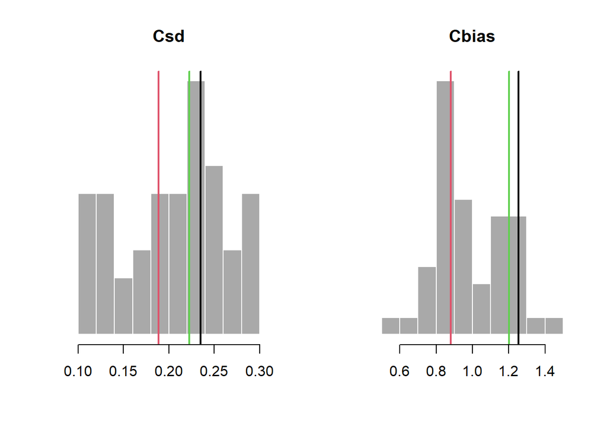

#### Time-Series

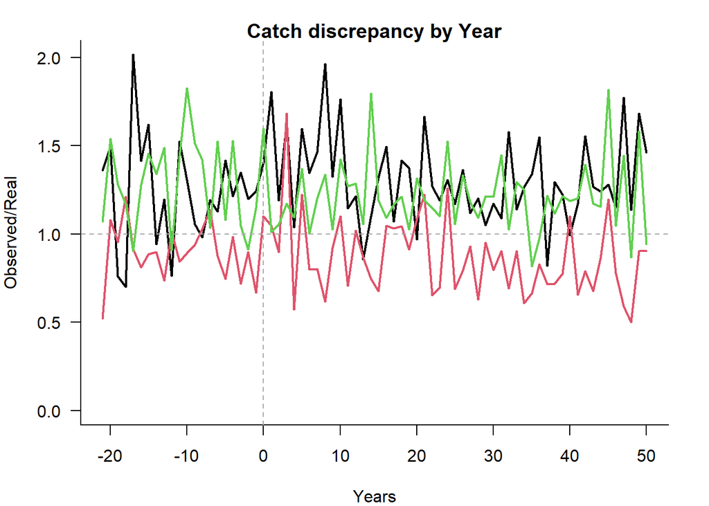

### Depletion Observations

#### Sampled Parameters

Histograms of 48 simulations of inter-annual variability in depletion observations (`Dobs`) and persistent bias in observed depletion (`Dbias`), with vertical colored lines indicating 3 randomly drawn values used in other plots:

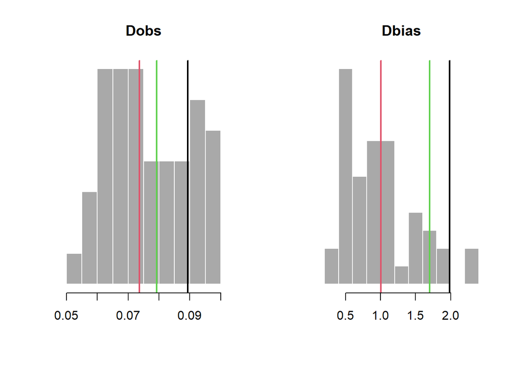

#### Time-Series

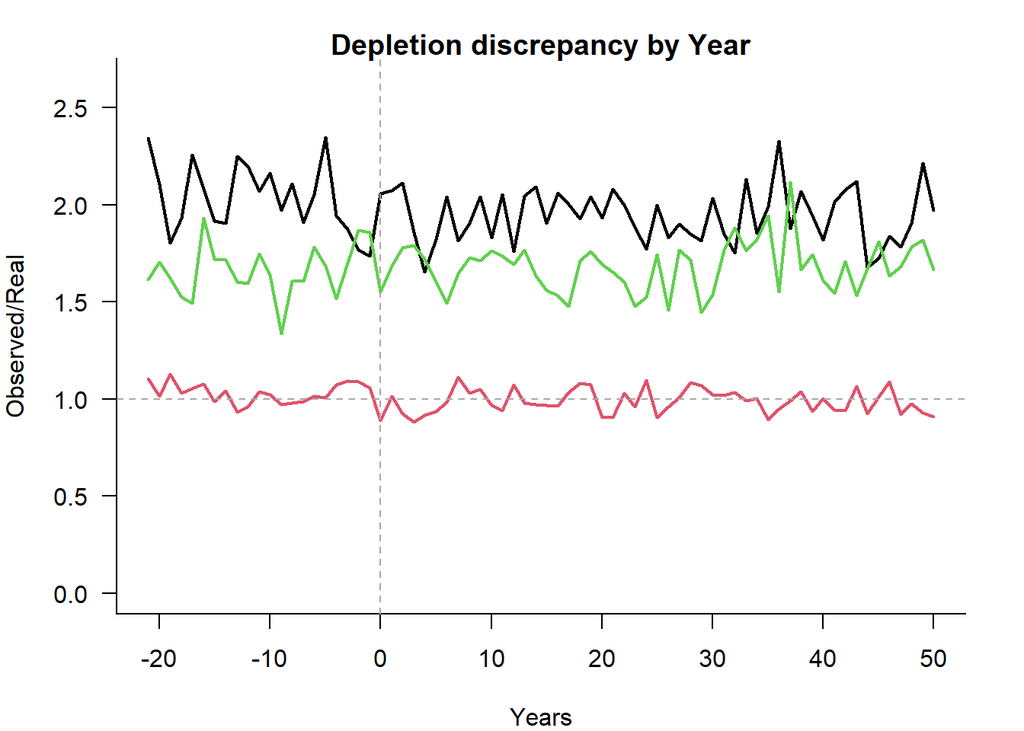

### Abundance Observations

#### Sampled Parameters

Histograms of 48 simulations of inter-annual variability in abundance observations (`Btobs`) and persistent bias in observed abundance (`Btbias`), with vertical colored lines indicating 3 randomly drawn values used in other plots:

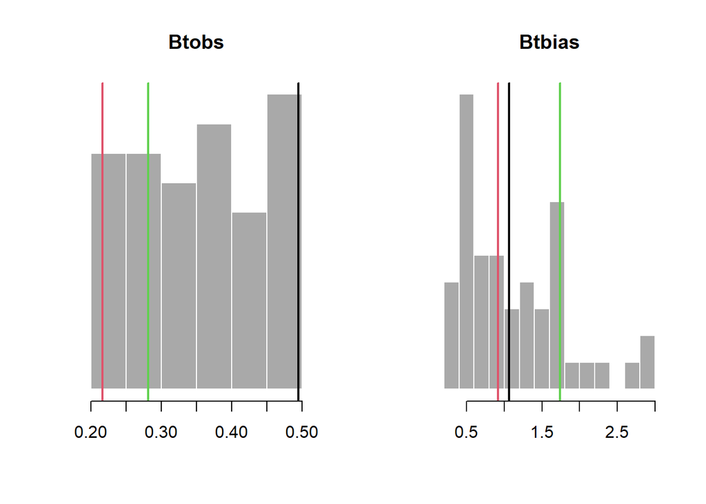

#### Time-Series

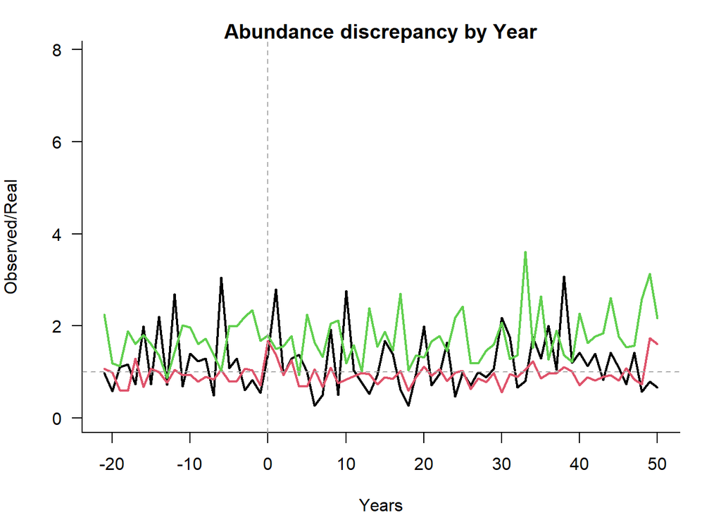

### Index Observations

#### Sampled Parameters

Histograms of 48 simulations of inter-annual variability in index observations (`Iobs`) and hyper-stability/depletion in observed index (`beta`), with vertical colored lines indicating 3 randomly drawn values used in other plots:

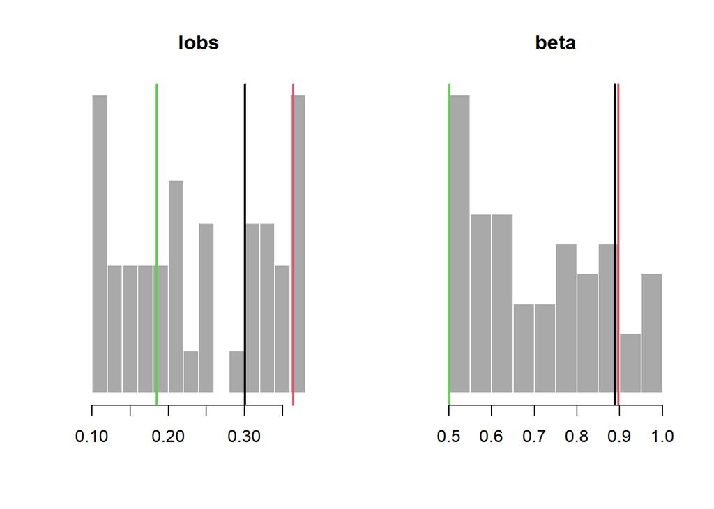

#### Time-Series

Time-series plot of 3 samples of index observation error:

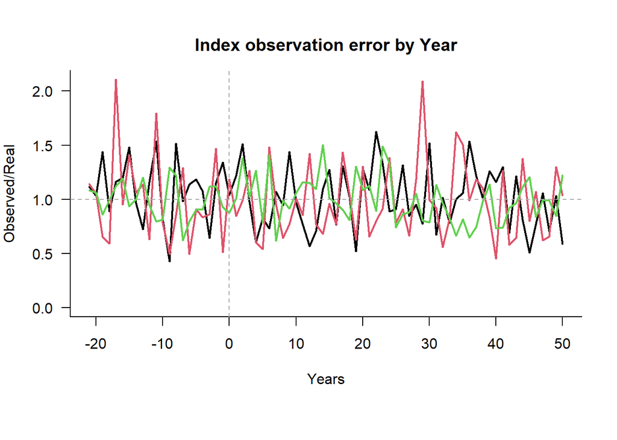

Plot showing an example true abundance index (blue) with 3 samples of index observation error and the hyper-stability/depletion parameter (`beta`):

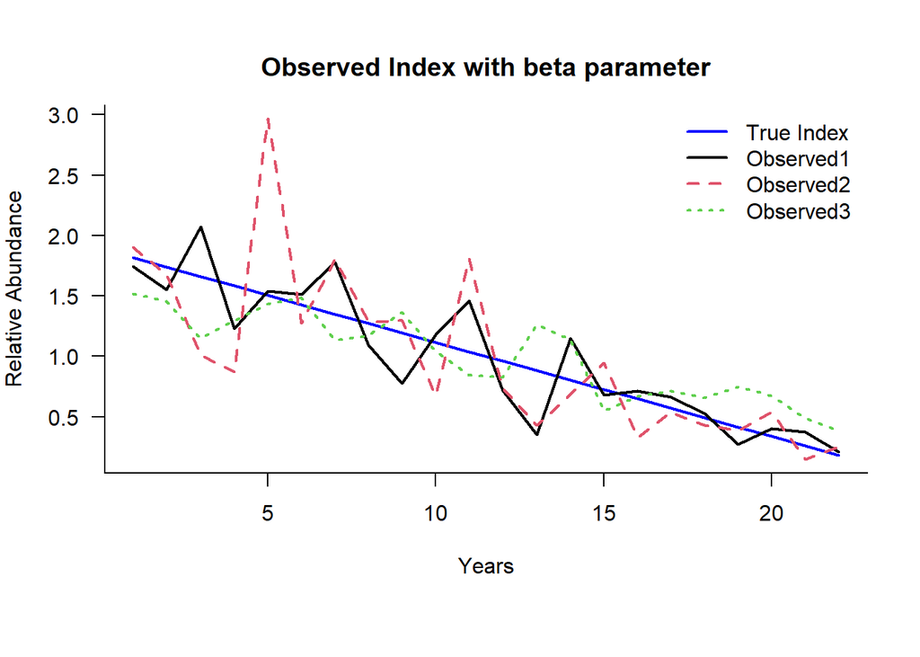